# Sales Prediction Exercise

2018-03-04

# 1 Purpose definition

The goal of this exercise is to predict sales for the coming year for different customers (groups of customers). I’ll use standard prediction techniques and practices to create predictive models, while explaining the decision I’ve made along the code as well.

The output will be available in an .Rmd and .html files.  
My documentation approach is the following: the .html output will show only limited amount of code, only snippets that are helpful for understanding the logic applied (others are “hidden” by the ‘echo = FALSE’ prefix for code chunks).  
For the full code base, please refer to the .Rmd file.

The presentation of the analysis is built of the following parts:  
1. Data review & cleaning  
2. Exploratory data analysis  
3. Featuring engineering  
4. Model & model selection  
5. Performance evaluation

An important feature of data analysis is that it is an iterative process - we are likely to go back to earlier steps once we learn something new about the data to expand what we did.  
This iterative process is by definition not very linear - presenting things as they evolved would be a very messy read for anyone.  
Hence, this document is created to capture the final state of the analysis - many of these smaller iterations are inherently lost unfortunately. Please keep this in mind when reading.

# 2 Data review & cleaning

After reading in the data, let’s take a glimpse at the data structure we’ll be working with:

```
## Observations: 544,387
## Variables: 6
## $ order_id      <int> 4852169, 3570597, 32096674, 2904402, 38369470, 1...
## $ contact_id    <int> 17846335, 18759585, 5025194, 29624779, 42287117,...
## $ purchase_date <chr> "2012-01-01", "2012-01-01", "2012-01-01", "2012-...
## $ product_id    <int> 3308032, 37220513, 10259603, 3308032, 3308032, 2...
## $ quantity      <int> 1, 2, 1, 1, 1, 2, 1, 4, 1, 1, 1, 1, 1, 1, 1, 1, ...
## $ sales_amount  <dbl> 18.71, 83.50, 19.95, 18.71, 18.71, 39.90, 45.56,...
```

| order_id | contact_id | purchase_date | product_id | quantity | sales_amount |
| --- | --- | --- | --- | --- | --- |
| 4852169 | 17846335 | 2012-01-01 | 3308032 | 1 | 18.71 |
| 3570597 | 18759585 | 2012-01-01 | 37220513 | 2 | 83.50 |
| 32096674 | 5025194 | 2012-01-01 | 10259603 | 1 | 19.95 |
| 2904402 | 29624779 | 2012-01-01 | 3308032 | 1 | 18.71 |
| 38369470 | 42287117 | 2012-01-01 | 3308032 | 1 | 18.71 |
| 10514626 | 34476502 | 2012-01-01 | 21913642 | 2 | 39.90 |

One thing to notice is that we have a field containing dates, however R treats it as a character column by default.

We’ll correct that in the next step, but before that let’s check if there is any observation that will require some fixing as well:

| variable | NA Count |
| --- | --- |
| order_id | 0 |
| contact_id | 0 |
| purchase_date | 0 |
| product_id | 0 |
| quantity | 0 |
| sales_amount | 0 |

No NAs, that’s good news. Before deciding whether the dataset is complete or not, let’s make sure all the sales & quantity values make sense, by checking how many 0-s we encounter.

First, for quantities:

```r
data %>%
  filter(quantity == 0) %>%
  summarize(count = n(),
            sum_sales_amount = sum(sales_amount))
```

| count | sum_sales_amount |
| --- | --- |
| 20 | 0 |

This looks very limited. Without further context on the data, I’ll just assume they are recording errors, and exlcude them for the dataset.

```r
data %>%
  filter(quantity != 0) %>%
  filter(sales_amount == 0) %>%
  summarize(count = n(),
            sum_quantity = sum(quantity))
```

| count | sum_quantity |
| --- | --- |
| 6947 | 7182 |

We are encountering many (6947 in total) observations for which sales_amount is 0. Interestingly, sometimes even the record quantity is larger than 1 for these.  
Although they are marginal compared to the number of all observations (500K+), a decision needs to be still made how to handle them, as they are likely misleading for any model in their current format.

There might be a reason behind having 0 values (one I can think of is they are being part of some kind of promotion), and this reason could actually be indicative of future sales (e.g. the promotion is for frequent shoppers etc.).  
In this case, features should be created out of these items to help enhance the model’s prediction.  
On the other hand, they might just be simple data issues. Deleted items still showing up as line items, incorrect prices (hence sales_amount), or anything similar.  
Right now we can simply and assume they actually represent wrong data - so by taking the easy path, I simply exclude them from further modeling efforts.

Applying the fixes before we continue:

```r
data <- data %>%
          filter(sales_amount > 0) %>%
          mutate(purchase_date = as.Date(purchase_date, "%Y-%m-%d")) %>%
          arrange(contact_id, purchase_date) %>%
          select(contact_id, order_id, purchase_date, product_id, quantity, sales_amount)
```

# 3 Data exploration

As standard practice, I’ll continue by visually exploring what’s in the data, that might be useful for sales prediction.

My starting hypothesis is that one of the most important features to understand is whether we are working returning customers - which materializes as having more than one purchase_date per contact_id (the other is the seasonality effect - more on that later).

The below table gives us a brief look into customers who are generating the most number of transactions:

| contact_id | total_line_items | transaction_count | unique_products | avg_quantity | median_quantity | avg_sales_amount | median_sales_amount | total_sales_amount |
| --- | --- | --- | --- | --- | --- | --- | --- | --- |
| 35244243 | 4432 | 4395 | 2206 | 1.055 | 1 | 64.56 | 39.95 | 286135 |
| 49141897 | 3840 | 3826 | 404 | 1.043 | 1 | 50.69 | 36.95 | 194645 |
| 25315468 | 2653 | 2634 | 241 | 1.083 | 1 | 38.14 | 33.95 | 101195 |
| 46092347 | 2610 | 2577 | 1283 | 1.089 | 1 | 71.84 | 49.95 | 187500 |
| 14316018 | 2370 | 2357 | 926 | 1.086 | 1 | 58.51 | 37.95 | 138675 |
| 35117040 | 2356 | 2348 | 213 | 1.081 | 1 | 46.99 | 36.36 | 110704 |
| 48751655 | 1867 | 1847 | 148 | 1.043 | 1 | 38.17 | 29.95 | 71271 |
| 15783338 | 1848 | 1839 | 318 | 1.084 | 1 | 39.80 | 31.95 | 73543 |
| 38936466 | 1253 | 1223 | 152 | 1.030 | 1 | 46.87 | 37.95 | 58722 |
| 42453396 | 1222 | 1205 | 271 | 1.124 | 1 | 48.84 | 37.95 | 59687 |

Below is a visualization of the distribution of transactions among customers, broken into two groups, one having more than 25 transactions, and one having less.

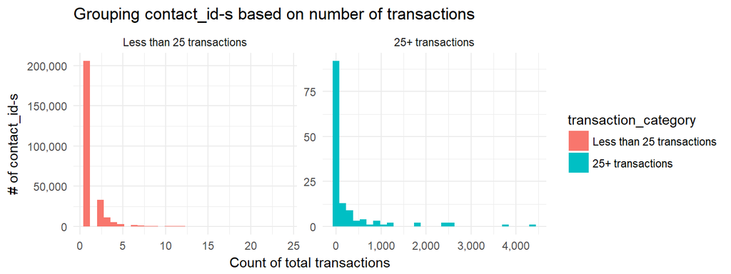

Maybe not suprisingly, total sales per contract_id do closely resemble a lognormal distribution:

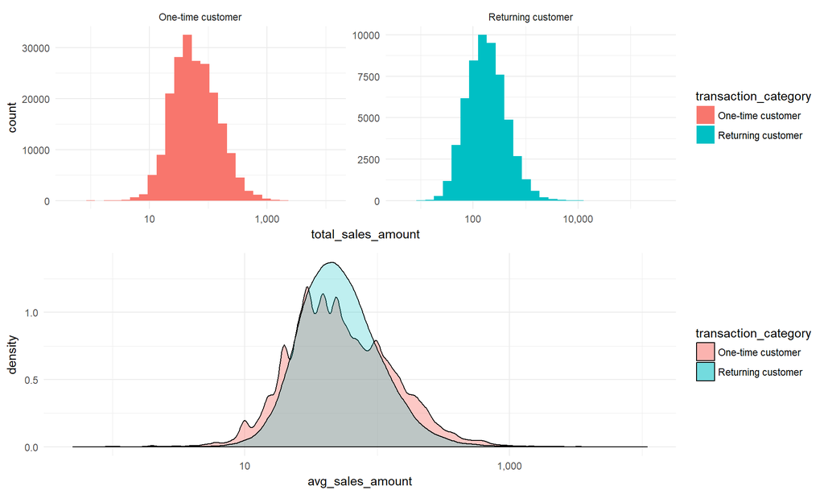

Returning customers do spend more in total - not much news, but it’s good to confirm with data.  
More interesting is the second plot, which show the distribution of *average spending* by customer-type split. Returning customers spend a bit more on average, but both distributions are skewed to the right - and larger transactions happen relatively more often to one-timers!

The second important factor to understand is how seasonality (basically time of purchase) is related to sales amounts. For modeling, we will build solutions that predict the the 2013 total (generally, the next year’s total) from 2012 data - so it’s good to know if there is any interesting dynamics going on for the time dimension of sales.

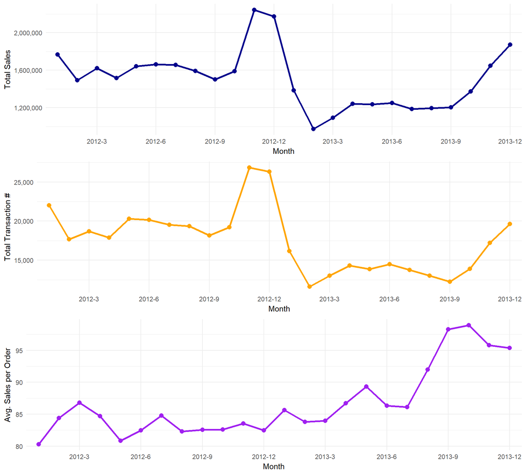

Total sales per month is visibly mostly driven by transaction count, which shows a lot of variation over time ( *reminder: here we talk about “total totals”, not per customer numbers*).  
On the other hand, avg. sales per order clearly showed some upwards trend, specially in the second half of 2013. This could mean either customers are buying more pricey items, or they are buying the same stuff as before, but per item costs have gone up.  
For a more detailed modeling, this is something worth exploring, however I am not going to go into further depths here.

# 4 Feature engineering

In this section, we’ll be getting the data in shape to use for prediction.

In this exercise, the goal is to predict a customers spending for a new year, based on historical spending patterns.  
We have two years in our dataset, 2012 & 2013 - given this, the setup will be rather simple - using everything we can from 2012, we want to predict a total sales_amount number for 2013 for a given customer.  
When working with time data, and trying to make predictions, it’s very important to avoid any “future leaks” - we only want to predict based on information that was available *a priori* compared to when we are making the prediction.  
Here, we basically already achieve this by data from 2012 as predictors for 2013 sales, so this is not something we need to worry about going forward.

So, first steps first: let’s calculate the per customer total spending for 2013.

```r
sales_2013 <- data %>%
                filter(year == 2013) %>%
                group_by(contact_id) %>%
                summarize(total_sales_2013 = sum(sales_amount, na.rm = TRUE))
```

A look at how the data looks arranged by top spenders on top:

| contact_id | total_sales_2013 |
| --- | --- |
| 46092347 | 109481 |
| 35244243 | 104800 |
| 32421253 | 76224 |
| 49141897 | 66870 |
| 27946735 | 56974 |

For 2012 we can start by building a couple of features that are rather “obvious” - total sales, transaction count, etc.:

```r
data_2012 <- data %>%
              filter(year == 2012)

features_2012 <- data_2012 %>%
                  group_by(contact_id) %>%
                  summarize(total_sales_2012 = sum(sales_amount, na.rm = T),
                            total_line_items_2012 = n(),
                            total_purchases_2012 = n_distinct(order_id),
                            total_quantity_2012 = sum(quantity, na.rm = T),
                            biggest_purchase_item = max(sales_amount, na.rm = T),
                            smallest_purchase_item = min(sales_amount, na.rm = T)
                            ) %>%
                  mutate(existing_2012_contact_id = "Y")
```

Again, look at how the data looks arranged by top spenders on top:

```r
features_2012 %>%
  arrange(desc(total_sales_2012), contact_id) %>%
  head(5)
```

| contact_id | total_sales_2012 | total_line_items_2012 | total_purchases_2012 | total_quantity_2012 | biggest_purchase_item | smallest_purchase_item | existing_2012_contact_id |
| --- | --- | --- | --- | --- | --- | --- | --- |
| 35244243 | 181335 | 2753 | 2731 | 2904 | 760.0 | 1.95 | Y |
| 49141897 | 127775 | 2613 | 2602 | 2720 | 379.9 | 4.33 | Y |
| 14316018 | 94263 | 1653 | 1642 | 1776 | 759.9 | 1.95 | Y |
| 46092347 | 78019 | 1156 | 1138 | 1244 | 623.9 | 2.71 | Y |
| 35117040 | 77952 | 1559 | 1552 | 1697 | 279.9 | 7.15 | Y |

The results are already promising - some customers are actually getting repeated in the top5 (e.g. contact_id 35244243 or 49141897), which is just a minor signal that there is likely to be a relationship between the two years’ spending patterns. I am going to explore this and a lot more futher after we are finished building all our features for prediction.

More features on yearly data:

```r
features_2_2012 <- data_2012 %>%
                    group_by(contact_id, order_id) %>%
                    summarize(sales_amount = sum(sales_amount),
                              most_expensive_line = max(sales_amount),
                              least_expensive_line = min(sales_amount),
                              count_lines = n()) %>%
                    group_by(contact_id) %>%
                    summarize(avg_sales_by_order_2012 = mean(sales_amount),
                              max_sales_by_order_2012 = max(sales_amount),
                              min_sales_by_order_2012 = min(sales_amount),
                              avg_most_expensive_line_by_order_2012 = mean(most_expensive_line),
                              avg_least_expensive_line_by_order_2012 = mean(least_expensive_line),
                              avg_line_item_count_by_order_2012 = mean(count_lines),
                              purchase_count = n())
```

A lot of features were created already - however, all of these used the data for the whole year.  
We’ve seen that seasonality is important - let’s build features that take this into account in some way:

```r
features_3_2012 <- data_2012 %>%
                    group_by(contact_id, purchase_month) %>%
                    summarize(sales_amount = sum(sales_amount)) %>%
                    group_by(contact_id) %>%
                    tidyr::spread(key = purchase_month, value = sales_amount, fill = 0, sep= "_")

new_feature_names <- paste(gsub("purchase_month", "sales_in_month", names(features_3_2012)), "2012", sep = "_")[2:13]
setnames(features_3_2012, old = names(features_3_2012)[2:13], new_feature_names)

features_4_2012 <- data_2012 %>%
                    group_by(contact_id, purchase_month) %>%
                    summarize(order_count = n_distinct(order_id)) %>%
                    group_by(contact_id) %>%
                    tidyr::spread(key = purchase_month, value = order_count, fill = 0, sep= "_")

new_feature_names <- paste(gsub("purchase_month", "orders_in_month", names(features_4_2012)), "2012", sep = "_")[2:13]
setnames(features_4_2012, old = names(features_4_2012)[2:13], new_feature_names)
```

Putting together what we have:

```r
df_for_prediction <- sales_2013 %>%
                      left_join(features_2012, by = "contact_id") %>%
                      left_join(features_2_2012, by = "contact_id") %>%
                      left_join(features_3_2012, by = "contact_id") %>%
                      left_join(features_4_2012, by = "contact_id")
```

Taking a look:

```r
head(df_for_prediction)
```

| contact_id | total_sales_2013 | total_sales_2012 | total_line_items_2012 | total_purchases_2012 | total_quantity_2012 | biggest_purchase_item | smallest_purchase_item | existing_2012_contact_id | avg_sales_by_order_2012 | max_sales_by_order_2012 | min_sales_by_order_2012 | avg_most_expensive_line_by_order_2012 | avg_least_expensive_line_by_order_2012 | avg_line_item_count_by_order_2012 | purchase_count | sales_in_month_1_2012 | sales_in_month_2_2012 | sales_in_month_3_2012 | sales_in_month_4_2012 | sales_in_month_5_2012 | sales_in_month_6_2012 | sales_in_month_7_2012 | sales_in_month_8_2012 | sales_in_month_9_2012 | sales_in_month_10_2012 | sales_in_month_11_2012 | sales_in_month_12_2012 | orders_in_month_1_2012 | orders_in_month_2_2012 | … |
| --- | --- | --- | --- | --- | --- | --- | --- | --- | --- | --- | --- | --- | --- | --- | --- | --- | --- | --- | --- | --- | --- | --- | --- | --- | --- | --- | --- | --- | --- | --- |
| 665 | 309.47 | NA | NA | NA | NA | NA | NA | NA | NA | NA | NA | NA | NA | NA | NA | NA | NA | NA | NA | NA | NA | NA | NA | NA | NA | NA | NA | NA | NA | … |
| 734 | 69.90 | NA | NA | NA | NA | NA | NA | NA | NA | NA | NA | NA | NA | NA | NA | NA | NA | NA | NA | NA | NA | NA | NA | NA | NA | NA | NA | NA | NA | … |
| 884 | 449.70 | NA | NA | NA | NA | NA | NA | NA | NA | NA | NA | NA | NA | NA | NA | NA | NA | NA | NA | NA | NA | NA | NA | NA | NA | NA | NA | NA | NA | … |
| 1930 | 399.20 | NA | NA | NA | NA | NA | NA | NA | NA | NA | NA | NA | NA | NA | NA | NA | NA | NA | NA | NA | NA | NA | NA | NA | NA | NA | NA | NA | NA | … |
| 2791 | 29.90 | 209.9 | 3 | 3 | 3 | 99.95 | 39.95 | Y | 69.95 | 99.95 | 39.95 | 69.95 | 69.95 | 1 | 3 | 0 | 0 | 99.95 | 39.95 | 0 | 0 | 0 | 0 | 0 | 0 | 69.95 | 0 | 0 | 0 | … |
| 2892 | 39.95 | NA | NA | NA | NA | NA | NA | NA | NA | NA | NA | NA | NA | NA | NA | NA | NA | NA | NA | NA | NA | NA | NA | NA | NA | NA | NA | NA | NA | … |

Not suprisingly, the features have many NAs:

| variable | NA Count |
| --- | --- |
| total_sales_2012 | 98342 |
| total_line_items_2012 | 98342 |
| total_purchases_2012 | 98342 |
| total_quantity_2012 | 98342 |
| biggest_purchase_item | 98342 |
| smallest_purchase_item | 98342 |
| existing_2012_contact_id | 98342 |
| avg_sales_by_order_2012 | 98342 |
| max_sales_by_order_2012 | 98342 |
| min_sales_by_order_2012 | 98342 |

[output cut: 30 more lines]

What does this mean? Remember, many of the customers are one-off purchasers, for whom no historical data will be available.  
Here (based on the assumption that the starting dataset was a complete), we know that all the NAs are actually true 0s, hence we can just substitue the NAs with 0s.

```r
df_for_prediction <- df_for_prediction %>%
                      mutate(existing_2012_contact_id = ifelse(!is.na(existing_2012_contact_id), "Yes", "No"))

df_for_prediction <- map(df_for_prediction, function(x) ifelse(is.na(x), 0, x)) %>% ##given vector x, if a value is NA it will be replaced by 0
                      as.data.table()
## Notes: this approach needs to be applied with caution! we don't want to replace non-number NAs with 0 for example.
## In this case it will be fine though - we already understand where NAs happen in the data


head(df_for_prediction)
```

| contact_id | total_sales_2013 | total_sales_2012 | total_line_items_2012 | total_purchases_2012 | total_quantity_2012 | biggest_purchase_item | smallest_purchase_item | existing_2012_contact_id | avg_sales_by_order_2012 | max_sales_by_order_2012 | min_sales_by_order_2012 | avg_most_expensive_line_by_order_2012 | avg_least_expensive_line_by_order_2012 | avg_line_item_count_by_order_2012 | purchase_count | sales_in_month_1_2012 | sales_in_month_2_2012 | sales_in_month_3_2012 | sales_in_month_4_2012 | sales_in_month_5_2012 | sales_in_month_6_2012 | sales_in_month_7_2012 | sales_in_month_8_2012 | sales_in_month_9_2012 | sales_in_month_10_2012 | sales_in_month_11_2012 | sales_in_month_12_2012 | orders_in_month_1_2012 | orders_in_month_2_2012 | … |
| --- | --- | --- | --- | --- | --- | --- | --- | --- | --- | --- | --- | --- | --- | --- | --- | --- | --- | --- | --- | --- | --- | --- | --- | --- | --- | --- | --- | --- | --- | --- |
| 665 | 309.47 | 0.0 | 0 | 0 | 0 | 0.00 | 0.00 | No | 0.00 | 0.00 | 0.00 | 0.00 | 0.00 | 0 | 0 | 0 | 0 | 0.00 | 0.00 | 0 | 0 | 0 | 0 | 0 | 0 | 0.00 | 0 | 0 | 0 | … |
| 734 | 69.90 | 0.0 | 0 | 0 | 0 | 0.00 | 0.00 | No | 0.00 | 0.00 | 0.00 | 0.00 | 0.00 | 0 | 0 | 0 | 0 | 0.00 | 0.00 | 0 | 0 | 0 | 0 | 0 | 0 | 0.00 | 0 | 0 | 0 | … |
| 884 | 449.70 | 0.0 | 0 | 0 | 0 | 0.00 | 0.00 | No | 0.00 | 0.00 | 0.00 | 0.00 | 0.00 | 0 | 0 | 0 | 0 | 0.00 | 0.00 | 0 | 0 | 0 | 0 | 0 | 0 | 0.00 | 0 | 0 | 0 | … |
| 1930 | 399.20 | 0.0 | 0 | 0 | 0 | 0.00 | 0.00 | No | 0.00 | 0.00 | 0.00 | 0.00 | 0.00 | 0 | 0 | 0 | 0 | 0.00 | 0.00 | 0 | 0 | 0 | 0 | 0 | 0 | 0.00 | 0 | 0 | 0 | … |
| 2791 | 29.90 | 209.9 | 3 | 3 | 3 | 99.95 | 39.95 | Yes | 69.95 | 99.95 | 39.95 | 69.95 | 69.95 | 1 | 3 | 0 | 0 | 99.95 | 39.95 | 0 | 0 | 0 | 0 | 0 | 0 | 69.95 | 0 | 0 | 0 | … |
| 2892 | 39.95 | 0.0 | 0 | 0 | 0 | 0.00 | 0.00 | No | 0.00 | 0.00 | 0.00 | 0.00 | 0.00 | 0 | 0 | 0 | 0 | 0.00 | 0.00 | 0 | 0 | 0 | 0 | 0 | 0 | 0.00 | 0 | 0 | 0 | … |

Making predictions on the zeros is one way to handle this issue - another one would be two build separate models for returning customers (a more complex one), and new customers (something very simple).  
We’ll see in the modeling phase which one makes more sense in this case.

## 4.1 Visual exploration of the “new” features

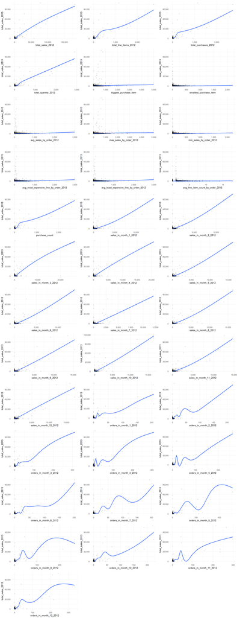

# 5 Modeling & model selection

For this part I’ll leverage the functionality given by Max Kuhn’s caret package, which gives easy access to many predictive methods, with possibility to tune the most important parameters.

Briefly, this step is of three parts: I’ll train & tune models with cross-validation.  
Once this is done, we can move onto selecting the best model - I’ll use a separate held-out set for this, to avoid measuring performance on the tuning set.  
Selection criteria will be simply RMSE, which I’ll try to optimize not just in general, but for separte sets of customer types as well.

## 5.1 Separating training and evaluation datasets

Let’s separate the different datasets we will use for the different steps. Caret helps us with this one as well, hence we don’t need to hustle with randomization.  
( *Note: At this point we would need to be cautious with time-series data and partitioning. However, the way the dataset was engineered, this is no longer a concern.*)

```r
training_ratio <- 0.6

set.seed(93) #for reproducibility
train_indices <- createDataPartition(y = df_for_prediction[["total_sales_2013"]],
                                     times = 1,
                                     p = training_ratio,
                                     list = FALSE)
data_train <- df_for_prediction[train_indices, ]
data_test <- df_for_prediction[-train_indices, ]

split_ratio <- 3/4

set.seed(93) #for reproducibility
perf_indices <- createDataPartition(y = data_test[["total_sales_2013"]],
                                     times = 1,
                                     p = split_ratio,
                                     list = FALSE)
data_test <- data_test[perf_indices, ]
data_perf <- data_test[-perf_indices, ]
```

## 5.2 Training & parameter tuning

When building models, I think using benchmarks is a good practice.  
Generally, I would break benchmarks into two categories:  
1. Base models, which can be used to evaulate the added value by more complex ones 2. “The best possible model”, usually something very complex for prediction. This can be later stripped of the extra features, and see if a simpler version (which might be easier to interpret) is able to provide similar performance metrics

We’ll build one from the 1st category - using only one predictor, total sales from 2012. This model will be a simple linear model (we’ve seen it in the previous visuals that the relationship is close to linear).

As discussed, for all models I’m using 10-fold CV to help avoid overfitting:

```r
train_control <- trainControl(method = "cv",
                              number = 10)
```

Earlier I’ve mentioned that the larger part of the customers are one-off purchasers - this makes prediction for them harder, as we don’t have anything to use for profiling that’s specific for them.

I was trying two approaches:  
1. “no history” is represented by 0s in the predictors  
2. training models only for the returning customers - for all others, we’ll just use the average spending in 2012 per customer as predictors for 2013

As it turned out, the second approach gave slightly better results, so when discussing the performance of different models, that’s what I’m going to focus on.

We can even ask the question whether it makes sense to bother for predicting for totally new customers? In real life scenarios, where there is $ impact, I would likely approach them with a very different approach, but in general, we can’t just disregard the majority of our customers.

*Note: the solution of using the avg. sales per customer from the previous year is very unsophisticated - we could tune this further easily. Simple ideas come to mind: account for trend YoY in sales, as well as take average only for one-off customers in 2012. In this case, however, I’m only using the basic approach, and focus on returning customer more.*

```r
data_train_full <- copy(data_train)
data_train_just_returning <- data_train %>%
                                filter(existing_2012_contact_id == "Yes") %>%
                                select(everything(), -existing_2012_contact_id)

avg_sales_2012 <- mean(df_for_prediction$total_sales_2012)
```

### 5.2.1 Benchmark model - simple glm

Training the model(s):

```r
#base model
set.seed(93)
glm_fit_full <- train(total_sales_2013 ~ total_sales_2012,
                       method = "lm",
                       data = data_train_full,
                       trControl = train_control)
set.seed(93)
glm_fit_just_returning <- train(total_sales_2013 ~ total_sales_2012,
                                 method = "lm",
                                 data = data_train_just_returning,
                                 trControl = train_control)
```

For all models, I’ll evalute performance later - so let’s just go onto our 2nd model.

### 5.2.2 Model 2 - glmnet with LASSO & ridge - parameter tuned

The second model we are going to train is glmnet, applying LASSO & Ridge regularization.  
This is a nice way to train a linear model, without worrying much about overfitting or variable selection - L1/L2 penalities will do that automatically.

```r
predictor_names <- names(data_train)[c(-1:-16)]
tune_grid <- expand.grid("alpha" = c(0, 1),
                         "lambda" = seq(from = 0.00, to = 1, by = 0.025))

set.seed(93)
glmnet_fit_full <- train(total_sales_2013 ~ . -contact_id,
                   method = "glmnet",
                   data = data_train,
                   trControl = train_control,
                   tuneGrid = tune_grid,
                   preProcess = c("center", "scale"))

set.seed(93)
glmnet_fit_just_returning  <- train(total_sales_2013 ~ . -contact_id,
                    method = "glmnet",
                   data = data_train_just_returning,
                   trControl = train_control,
                   tuneGrid = tune_grid,
                   preProcess = c("center", "scale"))
```

### 5.2.3 Model 3 - single decision tree

Moving into a bit different territory - decision trees.  
They are regularly used for classification problems, however they can be helpful for regression as well.  
The advantage of trees is that they are good at addressing non-linear patterns in the data - something we can only do in linear models by feature engingeering (e.g. adding polynomial terms).  
Single trees have some disadvantages as well, which I’ll discuss in the next part.

```r
set.seed(93)
rpart_fit_full <- train(total_sales_2013 ~ . -contact_id,
                   data = data_train,
                   method = "rpart",
                   tuneLength = 20,
                   trControl = train_control)

set.seed(93)
rpart_fit_just_returning <- train(total_sales_2013 ~ . -contact_id,
                   data = data_train_just_returning,
                   method = "rpart",
                   tuneLength = 20,
                   trControl = train_control)
```

### 5.2.4 Model 4 - Bagging (/ Random Forest)

So what is the (theoretical) problem with single trees? Well, they are implemented as “greedy” algorithms, which are prone to get stuck in local optimum.

My original implementation used Random Forest, which addresses this in two steps:  
1. By bootstrapping the dataset, and fitting many trees on the new samples. This makes the results more robust  
2. By always only using a subset of the predictors at each split. Simple bootstrapping might still produce very correlated trees, this helps with that

Fitting RF takes hours in the caret implementation unforunately, and as it turned out the results are not that good. So I switched back to simple treebag, which I could reran more easily as needed.

```r
set.seed(93)
rf_fit_full <- train(total_sales_2013 ~ . -contact_id,
                   data = data_train,
                   method = "treebag",
                   tuneLength = 20,
                   ntree = 250,
                   trControl = train_control)

set.seed(93)
rf_fit_just_returning <- train(total_sales_2013 ~ . -contact_id,
                   data = data_train_just_returning,
                   method = "treebag",
                   tuneLength = 20,
                   ntree = 250,
                   trControl = train_control)
```

## 5.3 Model selection

Let’s start by a summary visualization of the results, which can be seen below. RMSEs and plots are based on how the models performed on the held-out test sets, not the original training data.

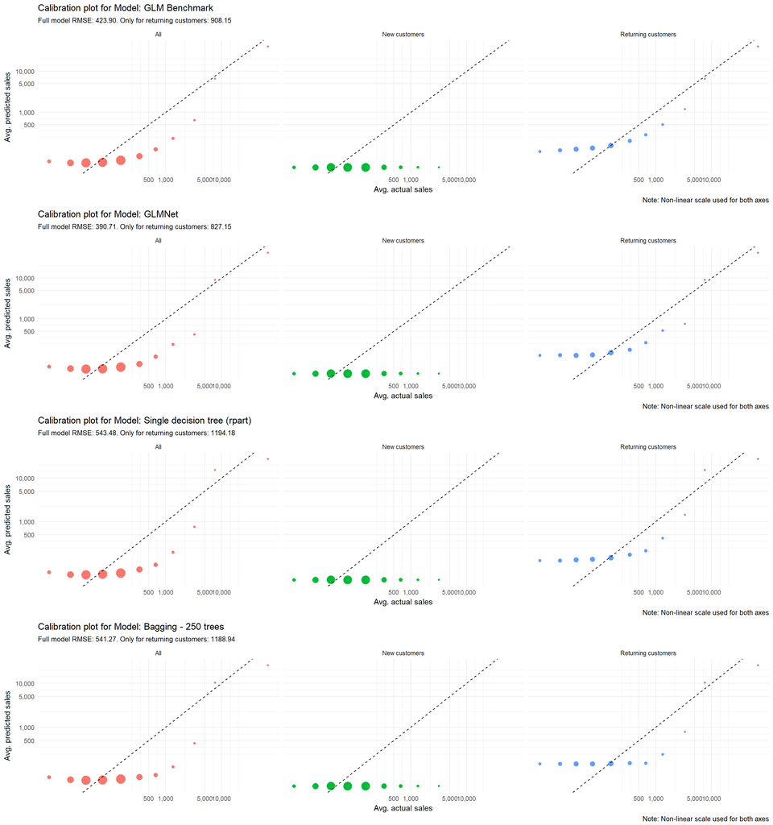

So.. first things first: how can we evaulate the overall performance of our models?  
The best RMSE achieved is ~830 - that looks very large!

But let’s remember for a moment that our data exhibits very large variaton as well:

```r
data_train_just_returning %>%
  summarize(avg = mean(total_sales_2013),
            std_dev = sd(total_sales_2013))
```

| avg | std_dev |
| --- | --- |
| 184.9 | 1282 |

This still doesn’t make me overly happy with the performance, but at least we know that it might not be that bad.

Another reason for the not-so-great performance can be read from the plots: the models are exhibiting strong bias for different customer groups!  
- For low-spenders, we overpredict on average  
- For mid-spenders, we tend to underpredict on average  
- While the biggest spenders are OK more or less

My original suspection was that this is due to the heavily skewed distribution of the sales data. However, after trying multiple correction (log transformations, or filtering top 1%) the models still exhibited similar behavior.  
The above explanation still makes sense to me - RMSE will penalize larger mispredictions, which are more likely to happen for the tail sales numbers.

Let’s assume for now that there is nothing we could do about the results, and we have to believe one of our models is truly the best. Which one should we choose?

Generally, the results are similar, but the GLMNet fit stands out a bit.

It’s a good question to ask ourselves whether that makes sense or not. At first, I expected the original RF to perform best - however, we can see that tree-based methods lag behind.

One explanation can be that the actual functional form that we are trying to estimate is linear - in this case, tree methods, however good they are at capturing nonlinearities, will be in disadvantage.

And if we take a look at the variable important scores extract from our models, we’ll see that the most imporant variables seem to be actually linear in total_sales_2013 when we visualized them earlier:

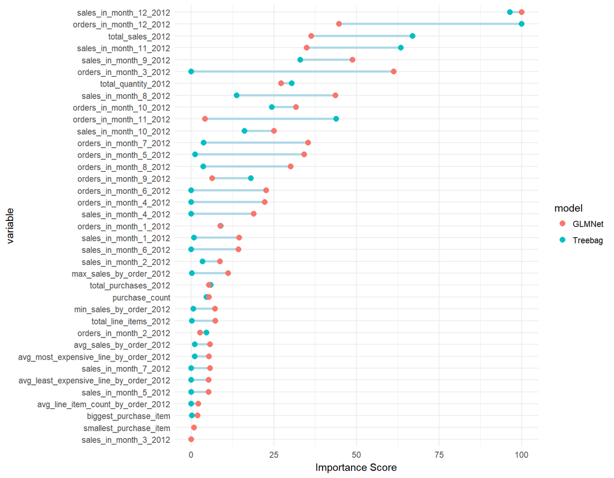

With this explanation (+based on best RMSE), I’m comfortable taking GLMNet as our best model.

# 6 Model performance evaluation and final words

## 6.1 Performance evaluation

Let do one final step of evalation, with the second held-out set we kept. This was needed, as the first one was used to select our best model, hence it might biased towards it as well.

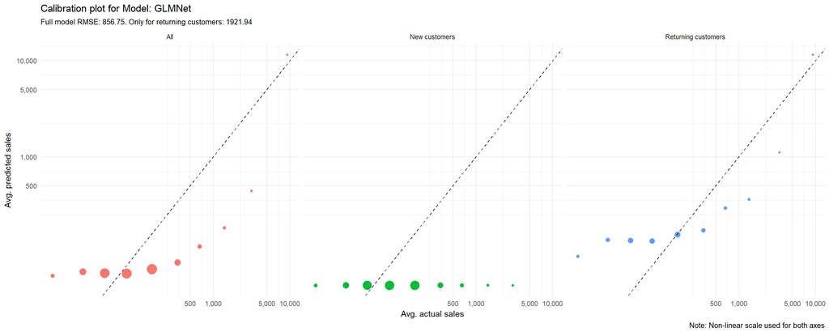

Okay… so our RMSE metrics look even worse than before.

Is that a concern regarding in terms of the previous “good” performance being just a result of chance?  
I don’t think so. This last sample is smaller - hence, a few big mispredictions can drive up RMSE.  
The plots show that the fit is similar to what we had before, hence I’m going to accept that this model is the best I could do now.

Let’s consider a couple of possible improvements:  
1. Enhanced scope - by more conscious definition of our target, we could filter to narrow the data, or build multiple models for different groups of customers  
2. More features - either we can create further ones from the dataset (e.g. try if 0 costs actually represent promotions), or see if we can get more features from external sources  
3. Selecting a better model form, which might fit the data better  
4. Depending on the final goal of the analysis, we might decide to create our own loss function. By defaulting to RMSE for model selection, we used one which is symmetric and non-linear – both of these attributes could be tailored to the exact need.

## 6.2 External validity?

With all prediction exercises, we need to ask ourselves whether our results would be applicable outside of the current dataset.  
In this case, there are some concerns regarding that - specially as we only used two years of data, so we can’t really predict how good we can perform over time.  
Also, as speciality of the data, majority customers were new - and as discussed, in lack of historical patterns, we are very limited in what we can do.